# Population growth 1

introduction to population growth

## Introduction to Population Growth Models

In ecology, understanding how populations may change over time is crucial. Two common models used to describe population growth are the exponential growth model of density-independent population growth and the logistic growth model fo density-dependent population growth.

### Exponential Population Growth

Exponential growth occurs when a population increases by a constant proportion over a fixed time period. It is often described by the equation:

$$N_t=N_0×e^{rt}$$
Where:

- $N_t$ is the population size at time $t$.
- $N_0$ is the initial population size.
- $r$ is the per capita rate of increase; also called the per capita growth rate, or instantaneous rate of increase.
- $e$ is the base of the natural logarithm.

Let’s visualize exponential population growth using R and ggplot2:

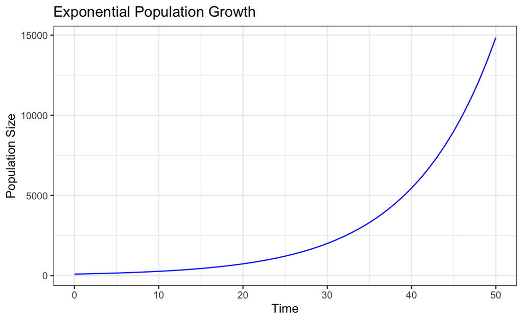

```r
# Define parameters
N0 <- 100 # Initial population size
r <- 0.1 # Growth rate
time <- seq(0, 50, by = 1) # Time period

# Calculate population size
Nt <- N0 * exp(r * time)

# Create data frame
df <- data.frame(time, Nt)

# Plot
ggplot(df, aes(x = time, y = Nt)) +
  geom_line(color = "blue") +
  labs(title = "Exponential Population Growth",
       x = "Time",
       y = "Population Size") +
  theme_bw()
```

As you can see in the figure above, exponential growth results in a continuously increasing population size as time proceeds.

### Logistic Population Growth

Logistic growth takes into account limiting factors that might depress the per-capita birth rate, increase the per-capita death rate, or both as populaiton density increases. Possible factors often include limited resource availability. The logistic growth model is described by the equation:

$${dN/dt}=rN(1-{N/K})$$

Where:

- $dN/dt$ represents the rate of change of the population over time.
- $N$ is the population size.
- $r$ is the intrinsic per capita growth rate, just as before.
- $K$ is the carrying capacity.

Let’s visualize logistic population growth using R and ggplot2:

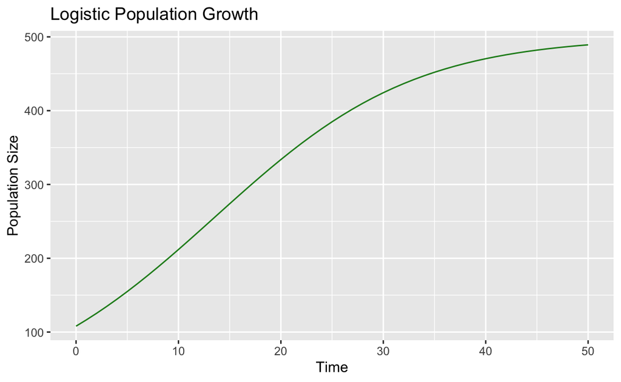

```r
# Define parameters
K <- 500 # Carrying capacity

# Define logistic growth function
logistic_growth <- function(N, r, K) {
  r * N * (1 - (N / K))
}

# Simulate logistic growth
simulated_data <- data.frame(time = time)
simulated_data$Nt <- NA

N <- N0
for (i in 1:length(time)) {
  dNdt <- logistic_growth(N, r, K)
  N <- N + dNdt
  simulated_data$Nt[i] <- N
}

# Plot
ggplot(simulated_data, aes(x = time, y = Nt)) +
  geom_line(color = "forestgreen") +
  labs(title = "Logistic Population Growth",
       x = "Time",
       y = "Population Size")
```

In the figure above, you can observe logistic population growth. Initially, the population grows exponentially, but as it approaches the carrying capacity, the growth rate slows down until it stabilizes near the carrying capacity.

### Density-Dependent Changes in Birthrate and Death Rate

To think a bit more about where carrying capacity comes from, we can decouple the density-dependence of per-capita birth and death rates in the logistic growth model. In general at small population sizes when resources are abundant, birth rates are high and death rates are low. This resulting in rapid population growth. However, as the population grows competition for resources increases, leading to decreased birth rates and increased death rates. We can model these changes as linear functions, or more complex relationships, but when the per-capita birth rates and death rates balance out, the system is at carrying capacity.

$$b = b_0 − aN$$
$$d = d_0 + cN$$

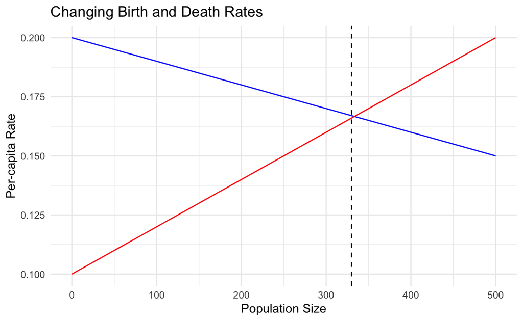

```r
# Define population size and parameters
population_size <- seq(0, 500, by = 10) # Population size
per_capita_birth_rate <- 0.2 - 0.0001 * population_size # Declining per-capita birth rate
per_capita_death_rate <- 0.1 + 0.0002 * population_size # Increasing per-capita death rate

# Calculate net growth rate (birth rate - death rate)
net_growth_rate <- per_capita_birth_rate - per_capita_death_rate

# Create data frame
df <- data.frame(population_size, per_capita_birth_rate, per_capita_death_rate)

# Find intersection point
intersection <- which.min(abs(per_capita_birth_rate - per_capita_death_rate))

# Calculate carrying capacity
carrying_capacity <- population_size[intersection]

# Plot
ggplot(df, aes(x = population_size)) +
  geom_line(aes(y = per_capita_birth_rate, color = "Per-capita Birth Rate")) +
  geom_line(aes(y = per_capita_death_rate, color = "Per-capita Death Rate")) +
  geom_vline(xintercept = carrying_capacity, linetype = "dashed", color = "black") +
  labs(title = "Changing Birth and Death Rates",
       x = "Population Size",
       y = "Per-capita Rate") +
  scale_color_manual(values = c("Per-capita Birth Rate" = "blue", "Per-capita Death Rate" = "red")) +
  theme_minimal() +
  theme(legend.position = "none")
```

### Allee effect

The Allee effect is a positive relation between average fitness and population size at low population densities (Drake and Kramer 2011). This means there is a *positive* relationship between the per capita birth rate rate and population size. This can result in positive density dependence rather than negative density dependence and typically happens at very low population sizes.

Allee effects can occur in populations of obligate outcrossers because at very low population sizes, male and female individuals are less likely to encounter each other or be pollinated by the same pollinator, and so mating frequency is very low. As population size increases, individuals are more likely to encounter each other, and mating increases.

We can model this by adding a term to our model, which incorporates a threshold population size $a$, below which the population growth rate is negative.

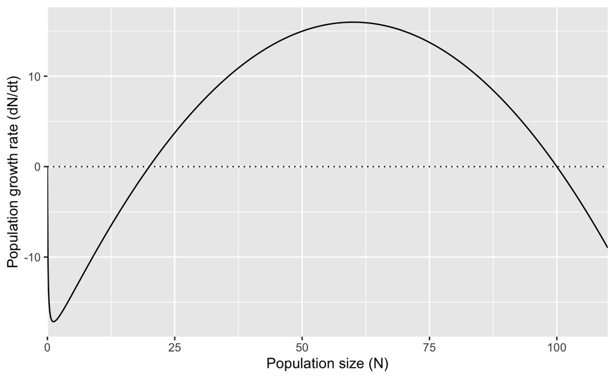

```r
## for simplicity, we let r=1 so we can ignore it here.
pgrA <- function(N, alpha, a, tau){ N*(1-alpha*N)*(1-(a+tau)/(N+tau)) }
myData <- data.frame( N=c(0, 110) ) # ggplot requires a data frame
p <- ggplot(data=myData, aes(x=N)) + # set the basic properties of the plot
  # in the stat_function, we indicate the parameters in our equation.
    stat_function(fun=pgrA, geom="line", n=1001,
                  args=list(alpha = 0.01, a=20, tau=.1)) +
  labs(y="Population growth rate (dN/dt)", x="Population size (N)") +
  #theme_classic() +
  geom_hline(yintercept=0, lty=3)+
  scale_x_continuous(expand = c(0, 0))
p
```